# Pacific Giant Salamander Habitat-Linked Population Changes

Alex Milward and Pat Byrne

11/24/2019

### Introduction

The Pacific Giant Salamander, *Dicamptodon tenebrosus*, is native to the Pacific Northwest of the United States, ranging from Northern California to Southern British Columbia (Gonder 1999). The size, weight, and distribution of Giant Salamanders, as well as salmonid species, have been studied in order to understand the effects of land use changes in the Andrews Experimental Forest on the Western slope of the Cascade Mountain range in Oregon (HJ Andrews Experimental Forest LTER 2011). Beginning in 1993, Gregory S. V. and Andrews Forest LTER started to model salamander population size and population distribution, as well as individual characteristics such as length and weight in the Mack Creek are of Andrews Experimental Forest. With accurate, long term data regarding these variables amongst the Pacific Giant Salamander, we can examine trends in population health and preference based on forest type and land use, as well as stream habitat classification (Gregory S. V. 2016). In this report, we used data collected by the Andrews Forest LTER Site to compare Pacific Giant Salamander population characteristics across old growth and clear cut forests, as well as more specific habitat classification, specifically cascades, pools, and stream side channels.

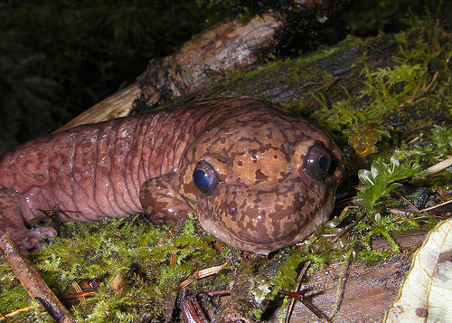

**Figure 1a**: Pacific Giant Salamander (Dicamptodon tenebrosus). Credit: [Oregon Wild](https://oregonwild.org/wildlife/pacific-giant-salamander)

### Data and Methods

Data for Pacific Giant Salamander population numbers and individual sizes were collected by annual survey of aquatic vertebrates in Andrews Experimental Forest, Oregon by the [Andrews Forest LTER Site](https://andrewsforest.oregonstate.edu/). Forest section type (OC and CC) and channel unit classification type (Pool, Cascade, and Side Channel), were defined by specific characteristics of each location. For more information on data and collection methods, see [metadata](https://portal.edirepository.org/nis/metadataviewer?packageid=knb-lter-and.4027.12).

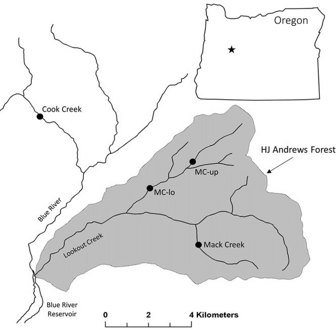

**Figure 1b**: Map of Andrews Experimental Forest, including Mack Creek section. Credit: [Dana Warren](https://www.researchgate.net/publication/314206020_Characterizing_short-term_light_dynamics_in_forested_headwater_streams)

This analysis was performed in Rstudio version 1.2.1335 running R version 3.6.1. The following packages were used in this report:

- tidyverse, version 1.2.1
- janitor, version 1.2.0
- effsize, version 0.7.6
- kableExtra, version 1.1.0
- ggridges, version 0.5.1

### Results

#### Temporal Trends in Abundance (1993-2017)

First, we examined how the population of Pacific Giant Salamanders studied had changed throughout the course of the study. Specifically, we wanted to visually check if the condition of the forest in which they lived (old growth vs. clear cut) had a clear influence on the overall abundance of salamanders. We created a plot of two timeseries of total number of salamanders counted in each of the sections between 1993 and 2017 (the years salamanders were observed), shown below in Figure 2.

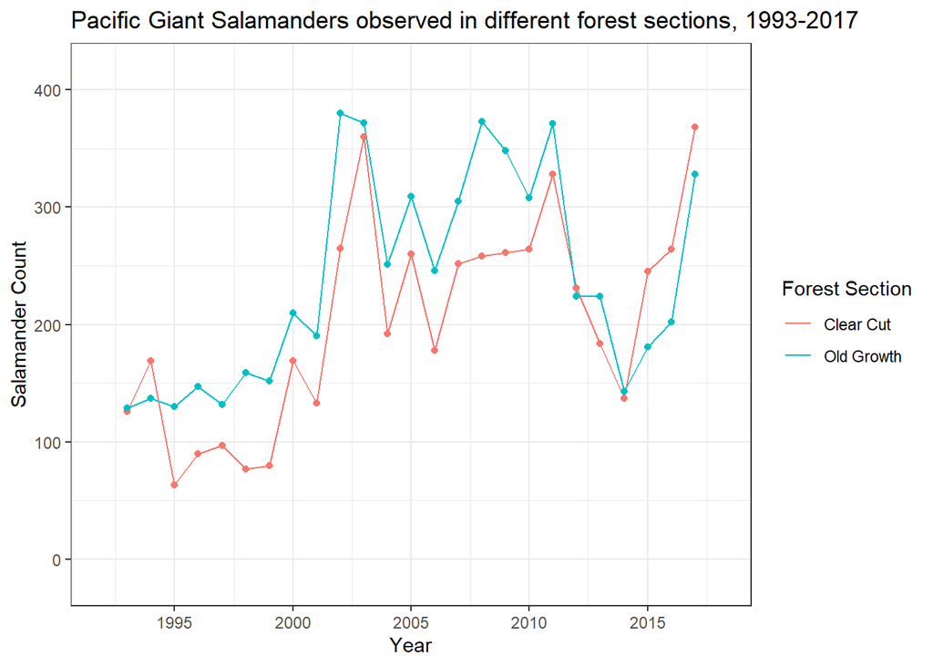

#### Spatial Trends in Salamander Abundance (2017)

To begin, we first created a table of the 2017 counts of salamanders found in three distinct channel areas designated by this study. We excluded ‘isolated pool’ salamanders to control solely for salamanders found in-stream. The table of counts and the proportion of observations in that type of forest section that the count in that channel area represents can be found below in Figure 3.

**Figure 3: Number and proportion of Giant Salamander observations in 2017 by location.** *For each combination of forest section and channel classification, whole numbers indicate the number of salamanders observed there, and percentages indicate the proportion of salamanders observed in that forest section that the whole number represents.*

| Salamander Observations by Location Forest Section | Salamander Observations by Location Channel Classification Cascade | Salamander Observations by Location Channel Classification Pool | Salamander Observations by Location Channel Classification Side Channel |
| --- | --- | --- | --- |
| Clear Cut | 247 (67%) | 31 (8%) | 90 (24%) |
| Old Growth | 201 (63%) | 45 (14%) | 74 (23%) |

Examining the table above, both forest sections show roughly similar breakdowns of salamanders observed. The majority were found in cascades, followed by side channels and lastly within pools. In the old growth section, proportionally and numerically more salamanders were found in pools and less in cascades and side channels. However, proportions were still fairly similar for both, as the biggest difference was 6% between pool observations.

In order to assess this slight yet apparent difference statistically, we conducted a Chi-Squared Test at the 95% confidence level. Interestingly, we found that there was no statisitically significant effect of forest section on salamander location within the river channel, but only by a small margin ($\chi^2$(2) = 5.541, *p* = 0.063). Considering the definition of a p-value, we can say that there is an approximately 6.3% chance that we recorded this distribution of salamanders within the channel if the populations were in fact identically distributed between forest section. This is a slim chance, yet still statistically insignificant nonetheless, and the lack of statistical significance perhaps reflects of how small that difference appeared to be at first glance.

#### Spatial Trends in Salamander Weight (2017)

We then turned to salamander weight to assess how the populations might be different in different forest conditions. We conducted a t-test at the 95% confidence level, and found that there was no statistically significant difference in mean weights of salamanders between the sections ((*t*(683.2) = -1.486, *p* = 0.138, n = 320 for old growth and 368 for clear cut)).

Combined with the results of our Chi-Squared test above, we do not appear to have found any evidence for the effect that forest type may have on salamander populations, both in their abundance and mean weight. However, these observations are only for the year 2017, and repeating this study with data from different years would be prudent given the calculated p-values are on the cusp of statistical significance.

Next, we moved on to an examination of how location within the river channel might influence salamander weight. We first created a ridgeline plot of the distribution of salamander weights based on channel location, which can be found below in Figure 4. It is worth noting that the plots are fitted estimates of kernel density. This explains why the distributions extend past zero, even though that has no real-world meaning - a salamander cannot have negative weight. These plots are therefore better for assessing the general shape of the distribution of weights rather than computing the probability that the weight of a random salamander is within a certain range.

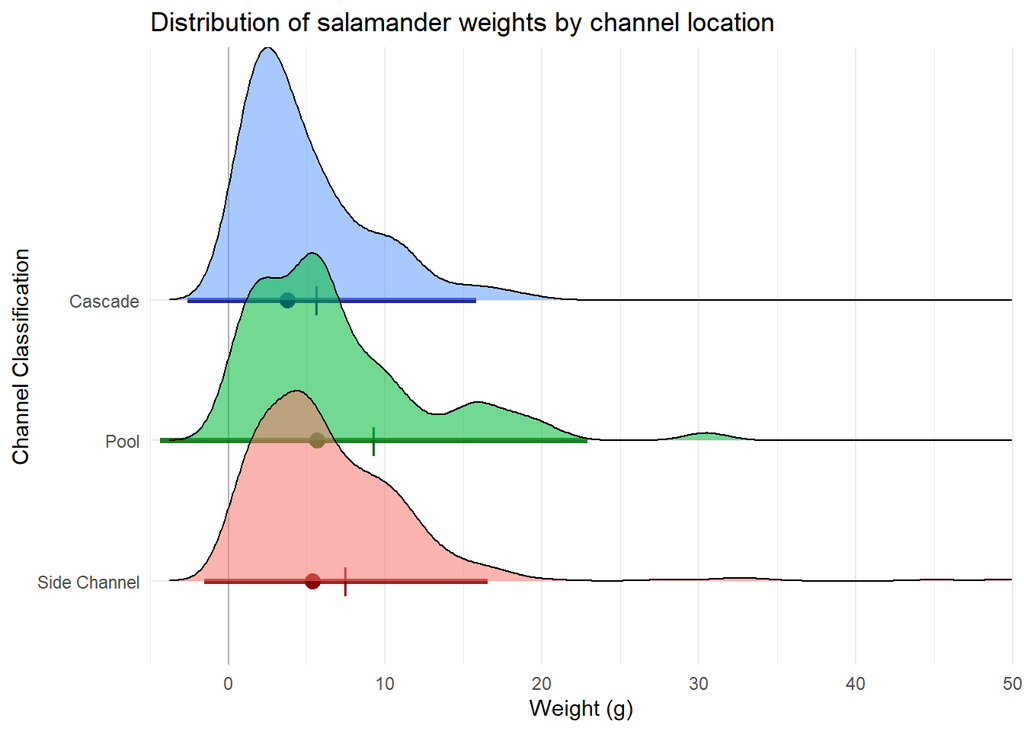

**Figure 4: Distribution of Pacific Giant Salamander weights based on measurement location within the river channel.** *Blue corresponds to salamanders recorded in the cascade section, green in the pool section, and red in the side channel section. The vertical tick beneath the distribution of the matching color shows to the location of the mean of that distribution, the horizontal line extending in either direction shows the width of one standard deviation from the mean, and the solid dot shows the location of the median.*

Examining Figure 4 above, we can see that the distributions of weights were roughly consistent in shape as the each display a positive skew (evidenced by the relative positions of the median and mean as well as visual appearances). They are also fairly consistent in position, having a peak roughly between 0 and 10. They do appear to have different spreads however, as the width of one standard deviation appears much greater for pool weights than the other two.

### References

Gonder, M. (1999). *Dicamptodon ensatus - California Giant Salamander*. Animal Diversity Web. Accessed December 02, 2019

Gregory S. V. (2016). *Aquatic Vertebrate Population Study in Mack Creek, Andrews Experimental Forest, 1987 to present*. Environmental Data Initiative. https://doi.org/10.6073/pasta/5de64af9c11579266ef20da2ff32f702. Dataset accessed 11/19/2019.